# Problem Set 2

Author

### Instructions

#### How to **complete** this assignment.

- Attempt each exercise in order.
- In each code chunk, if you see “# INSERT CODE HERE”, then you are expected to add some code to create the intended output (Make sure to erase “# INSERT CODE HERE” and place your code in its place).
- If my instructions say to “Run the code below…” then you do not need to add any code to the chunk.
- Many exercises may require you to type some text below the code chunk, interpreting the output and answering the questions.
- Please follow the rules from the course syllabus regarding seeking help with this assignment.

#### How to **submit** this assignment.

- When you are finished, click the “Render” button at the top of this panel. If there are no errors, an HTML file should pop up after a few seconds.
- Take a look at the resulting HTML file that pops up. Make sure everything looks correct, your name is listed at the top, and that there is no ‘junk’ code or output.
- Save the HTML file (to your local computer, and/or to a cloud location) as: **Problem Set 2 “Insert Your Name”**.
- Before you upload the file to HuskyCT, you will need to zip/compress the file.
- Upload the problem set zipped/compressed HTML to HuskyCT. **Do not** upload the original .qmd version.
- This assignment is **due Monday, February 24, 2025, no later than 4:00 pm Eastern**. Points will be deducted for late submissions.
- TIP: Start early so that you can troubleshoot any issues with knitting to HTML.

#### Grading Rubric

There are 8 possible points on this assignment.

**Baseline (C level work)**

- Your .qmd file knits to HTML without errors.
- You answer questions correctly but do not use complete sentences.
- There are typos and ‘junk code’ throughout the document.
- You do not put much thought or effort into the Reflection answers.

**Average (B level work)**

- You use complete sentences to answer questions.
- You attempt every exercise/question.

**Advanced (A level work)**

- Your code is simple and concise.
- Unnecessary messages from R are hidden from being displayed in the HTML.
- Your document is typo-free.
- At the discretion of the instructor, you give exceptionally thoughtful or insightful responses.

In this lab, you will work with data on schools from the Common Core of Data (CCD), collected by the National Center for Education Statistics. You can read more about the CCD and and find documentation on this datafile [here](https://nces.ed.gov/ccd/pubschuniv.asp).

We are working with the 2013-14 dataset. A variable codebook for the CCD, which will explain what each column represents in the data file is located in the “flat file” in the record layout column and 2013-14 row.

#### **Exercise 1. Load the appropriate packages and load the data. (1 points)**

```r
#insert code here
library(tidyverse)
schools <- read_csv("Problem Set 2 Data.csv")
```

**ANSWER:**

#### **Exercise 2. (A) Make a new variable sch_type that has the value “Charter”, “Magnet” or “TPS”, to specify if the school is a charter, magnet or traditional public school. (B) How many schools of each of these three types are in our area? (C) Make a table that show the number of schools of each of the three school types that are missing data for free lunch. (1.5 points)**

```r
#insert code here
#a
schools <- schools %>%
  mutate(sch_type = case_when(
    MAGNET == 1 ~ "Magnet",
    CHARTR == 1 ~ "Charter",
    TRUE ~ "TPS"))
#b
schools %>%
  count(sch_type)
```

```
# A tibble: 3 × 2
  sch_type     n
  <chr>    <int>
1 Charter      3
2 Magnet      28
3 TPS         91
```

```r
#c
schools %>%
  filter(is.na(FRELCH)) %>%
  count(sch_type)
```

```
# A tibble: 0 × 2
# ℹ 2 variables: sch_type <chr>, n <int>
```

**ANSWER:**

#### **Exercise 3. (A) How many schools are elementary schools? Middle schools? High schools? Other? Missing? (B) How many schools are eligible for Title I status? Summarize the count of schools in each category. (1 points)**

```r
#insert code here
#a
schools %>%
  count(LEVEL)
```

```
# A tibble: 4 × 2
  LEVEL     n
  <dbl> <int>
1     1    69
2     2    13
3     3    26
4     4    14
```

```r
#b
schools %>%
  group_by(TITLEI) %>%
  count()
```

```
# A tibble: 2 × 2
# Groups:   TITLEI [2]
  TITLEI     n
   <dbl> <int>
1      1    78
2      2    44
```

**ANSWER:**

#### **Exercise 4. (A) Create new variables that compute the percentage of students who are Black, White, Hispanic, Asian or another race (call this variable “other”), and the percentage of students receiving free OR reduced price lunch. (B) Visualize these data to see the variability of each of these variables (Hint: Use geom_histogram). (1 points)**

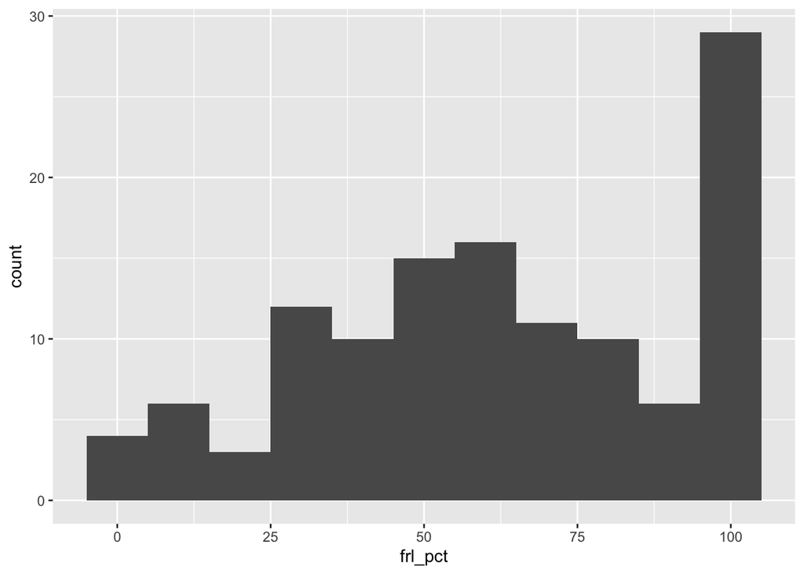

```r
#insert code here
schools <- mutate(schools,
              frl_pct = 100 * TOTFRL/MEMBER,
              black_pct = 100 * BLACK/TOTETH,
              white_pct = 100 * WHITE/TOTETH,
              hisp_pct = 100 * HISP/TOTETH,
              asian_pct = 100 * ASIAN/TOTETH,
              other_pct = 100 * (AM + PACIFIC + TR)/TOTETH
              )
#b
# Freqpoly also fine below, look for "reasonable" value of binwidth in either geom
# Also fine to put all on one plot

schools %>%
  filter(!is.na(frl_pct)) %>%
  ggplot(aes(x=frl_pct)) +
  geom_histogram(binwidth = 10)
```

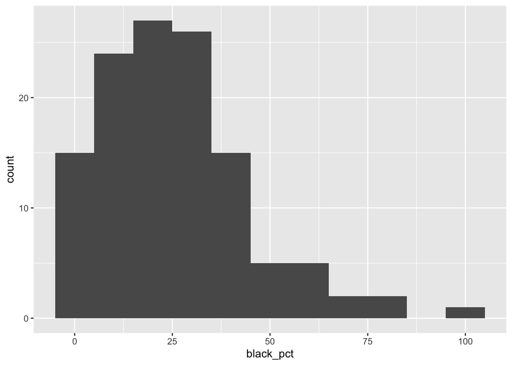

```r
schools %>%
  filter(!is.na(black_pct)) %>%
  ggplot(aes(x=black_pct)) +
  geom_histogram(binwidth = 10)
```

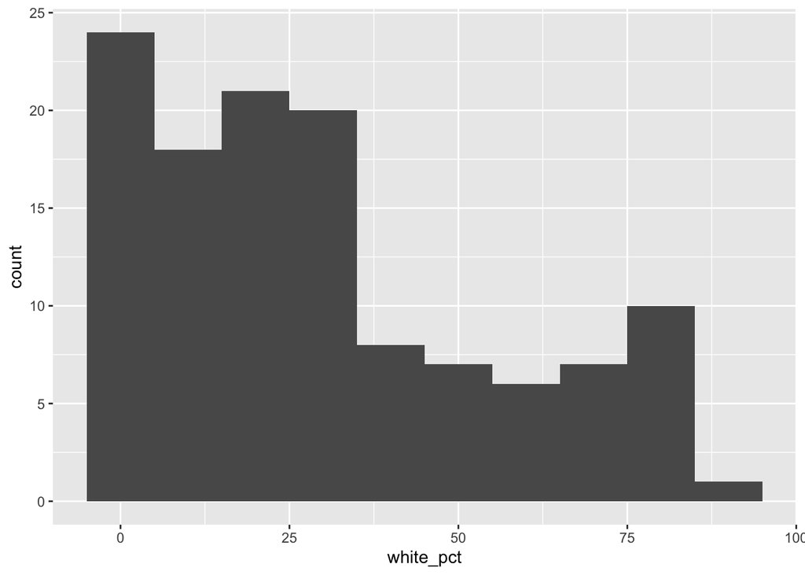

```r
schools %>%
  filter(!is.na(white_pct)) %>%
  ggplot(aes(x=white_pct)) +
  geom_histogram(binwidth = 10)
```

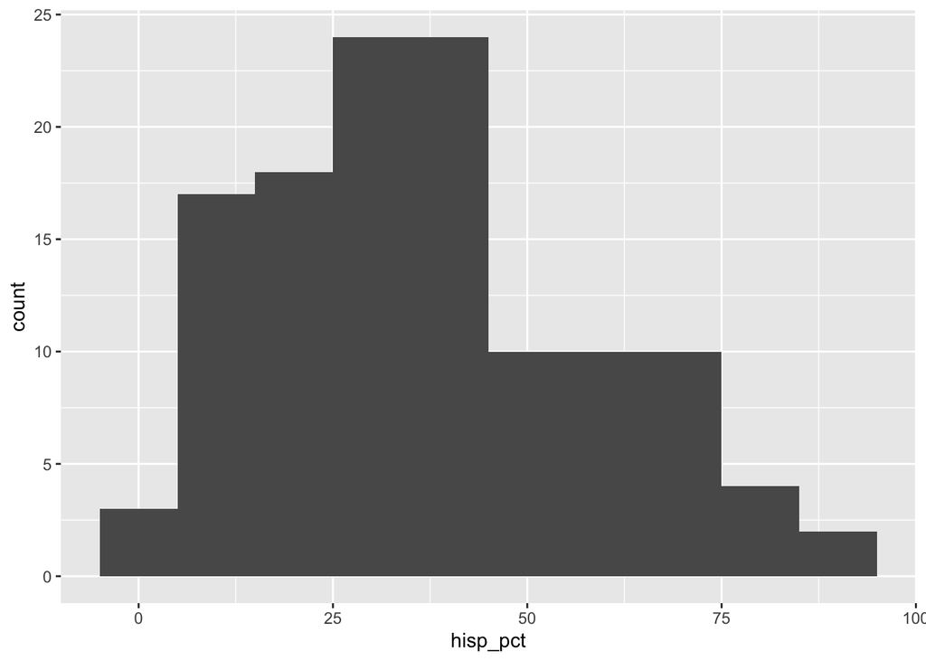

```r
schools %>%
  filter(!is.na(hisp_pct)) %>%
  ggplot(aes(x=hisp_pct)) +
  geom_histogram(binwidth = 10)
```

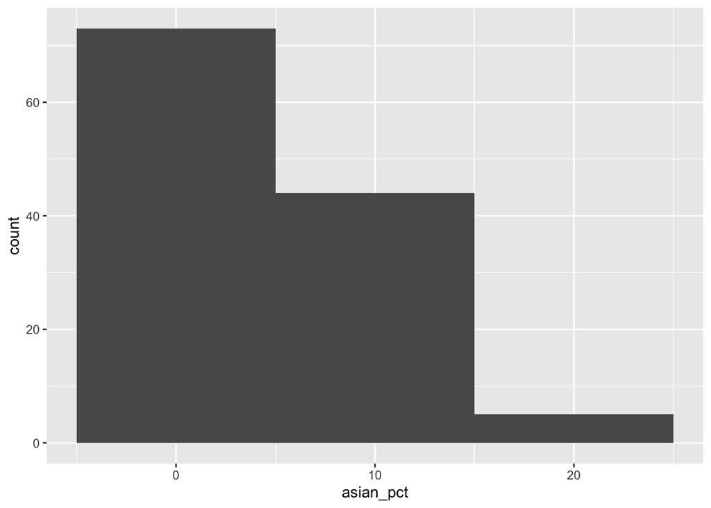

```r
schools %>%
  filter(!is.na(asian_pct)) %>%
  ggplot(aes(x=asian_pct)) +
  geom_histogram(binwidth = 10)
```

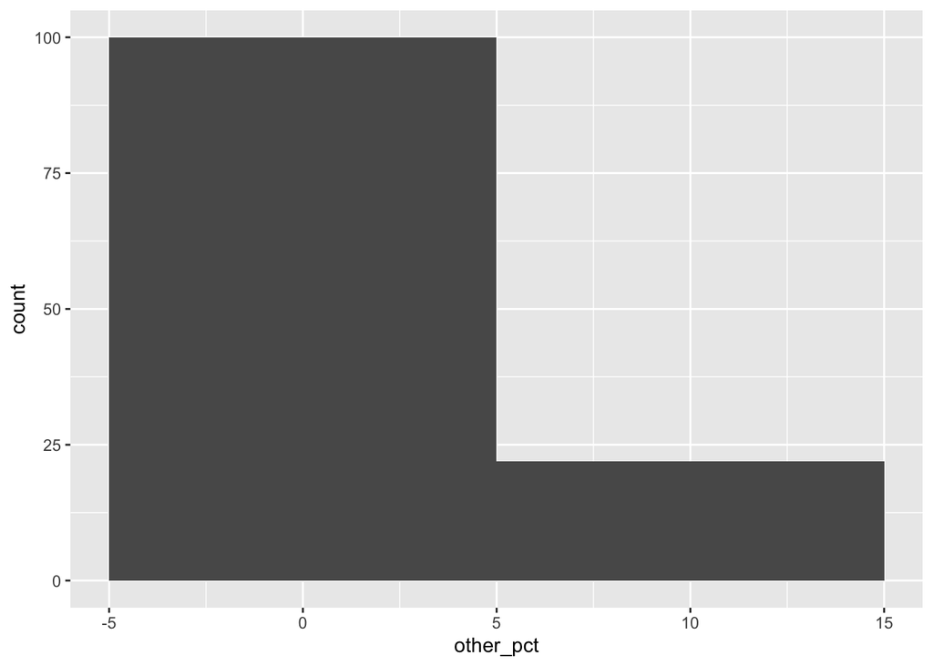

```r
schools %>%
  filter(!is.na(other_pct)) %>%
  ggplot(aes(x=other_pct)) +
  geom_histogram(binwidth = 10)
```

**ANSWER:**

#### **Exercise 5. Visualize the variation in the percent of students receiving free lunch (frelch) for magnet schools, TPS, and charter schools (Hint: Use geom_boxplot). (1 points)**

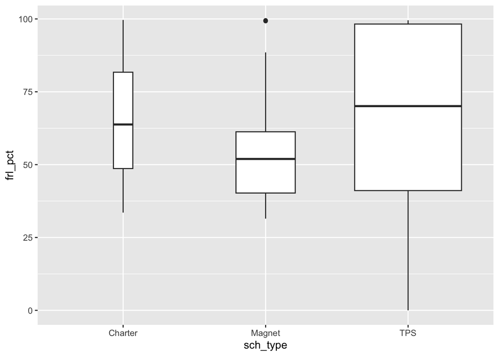

```r
#insert code here
schools %>%
  filter(!is.na(MEMBER)) %>%
  #mutate(frl_pct = totfrl / member) %>%
  ggplot(mapping = aes(x=sch_type, y = frl_pct)) +
    geom_boxplot(varwidth = TRUE)
```

**ANSWER:**

#### **Exercise 6. Visualize the variation in the percent of students of each race and ethnicity in the data file (Black, White, Hispanic, Asian and Other) for each of the type of schools (magnet, TPS and charter) (Hint: Use geom_boxplot). (1 points)**

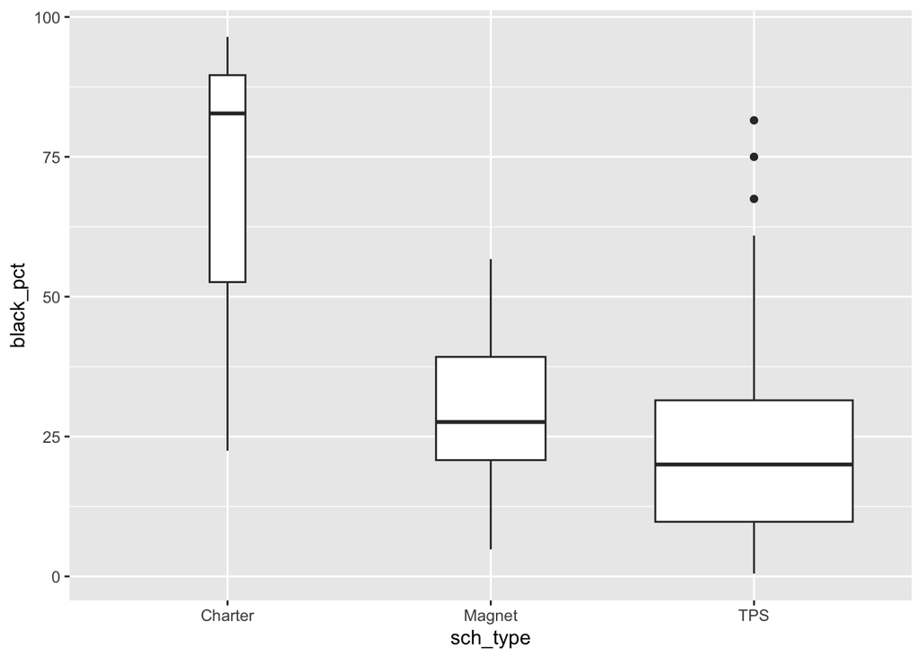

```r
#insert code here
schools %>%
  ggplot(mapping = aes(x=sch_type, y = black_pct)) +
    geom_boxplot(varwidth = TRUE, na.rm=TRUE)
```

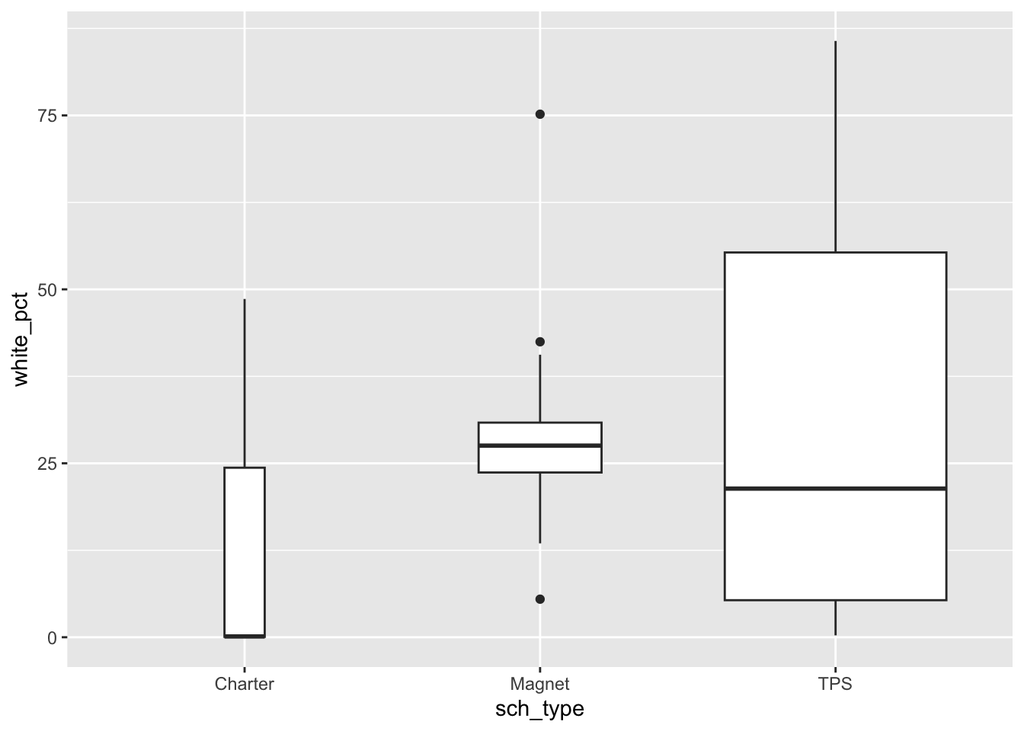

```r
schools %>%
  ggplot(mapping = aes(x=sch_type, y = white_pct)) +
    geom_boxplot(varwidth = TRUE, na.rm=TRUE)
```

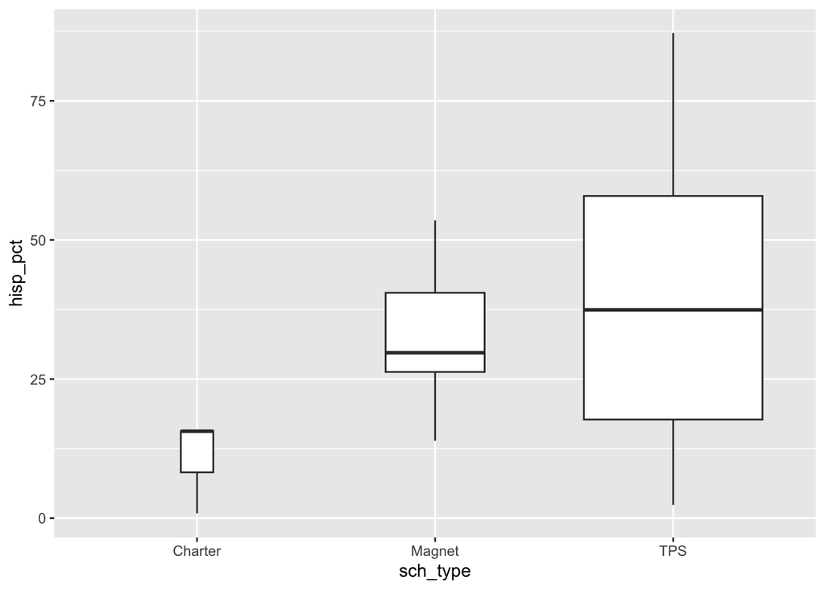

```r
schools %>%
  ggplot(mapping = aes(x=sch_type, y = hisp_pct)) +
    geom_boxplot(varwidth = TRUE, na.rm=TRUE)
```

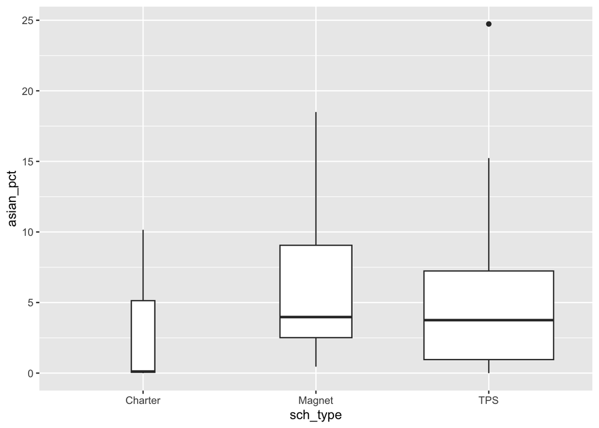

```r
schools %>%
  ggplot(mapping = aes(x=sch_type, y = asian_pct)) +
    geom_boxplot(varwidth = TRUE, na.rm=TRUE)
```

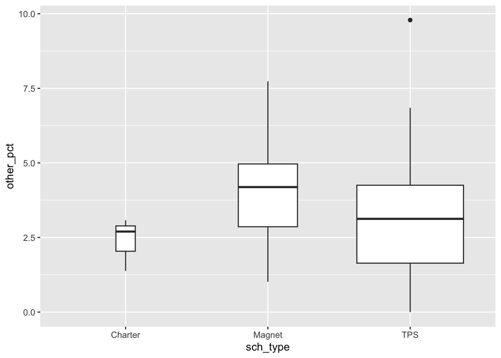

```r
schools %>%
  ggplot(mapping = aes(x=sch_type, y = other_pct)) +
    geom_boxplot(varwidth = TRUE, na.rm=TRUE)
```

**ANSWER:**

#### **Exercise 7. Reflection (1 points)**

##### **What were the easiest and hardest parts of this assignment?**

**ANSWER:**

##### **With more R skills what types of questions could you answer using this dataset?**

**ANSWER:**

#### **Exercise 8. Reflection (1 points)**

##### **What are some questions you have about this dataset? What information would you add to the dataset, if you could?**

**ANSWER:**